# Mini-Project #02: Making Backyards Affordable for All

# What is the last year in which the NYC CBSA had the most data scientists in the country? In recent, the San Francisco CBSA has had the most data scientists.

```r
library(dplyr)

wages_5182 <- WAGES |>
  filter(INDUSTRY == 5182)

cbsa_year_totals <- wages_5182 |>
  group_by(YEAR, FIPS) |>
  summarise(total_emp = sum(EMPLOYMENT, na.rm = TRUE), .groups = "drop")

top_cbsa_per_year <- cbsa_year_totals |>
  group_by(YEAR) |>
  slice_max(total_emp, n = 1) |>
  ungroup() |>
  arrange(YEAR)

# Step 4: Optional: Map CBSA FIPS to names (manual mapping for top CBSA codes)
cbsa_map <- data.frame(
  FIPS = c("C3562", "C1910", "C4186", "C1206"),
  NAME = c("New York-Newark-Jersey City, NY-NJ-PA Metro Area",
           "San Jose-Sunnyvale-Santa Clara, CA Metro Area",
           "San Francisco-Oakland-Berkeley, CA Metro Area",
           "Austin-Round Rock-Georgetown, TX Metro Area")
)

top_cbsa_named <- top_cbsa_per_year |>
  left_join(cbsa_map, by = "FIPS") |>
  select(YEAR, FIPS, NAME, total_emp)

# Step 5: Find the last year NYC CBSA was #1
nyc_last_year <- top_cbsa_named |>
  filter(str_detect(NAME, "New York")) |>
  slice_max(YEAR) |>
  pull(YEAR)


# View the table of top CBSA per year
top_cbsa_named|>
  datatable(options = list(searching = FALSE, info = FALSE))
```

|  | YEAR | FIPS | NAME | total_emp |
| --- | --- | --- | --- | --- |
| 1 | 2009 | C3562 | New York-Newark-Jersey City, NY-NJ-PA Metro Area | 16349 |
| 2 | 2010 | C1910 | San Jose-Sunnyvale-Santa Clara, CA Metro Area | 13238 |
| 3 | 2011 | C1910 | San Jose-Sunnyvale-Santa Clara, CA Metro Area | 13283 |
| 4 | 2012 | C3562 | New York-Newark-Jersey City, NY-NJ-PA Metro Area | 14423 |
| 5 | 2013 | C3562 | New York-Newark-Jersey City, NY-NJ-PA Metro Area | 14251 |
| 6 | 2014 | C3562 | New York-Newark-Jersey City, NY-NJ-PA Metro Area | 17828 |
| 7 | 2015 | C3562 | New York-Newark-Jersey City, NY-NJ-PA Metro Area | 18922 |
| 8 | 2016 | C4186 | San Francisco-Oakland-Berkeley, CA Metro Area | 16369 |
| 9 | 2017 | C4186 | San Francisco-Oakland-Berkeley, CA Metro Area | 18089 |
| 10 | 2018 | C4186 | San Francisco-Oakland-Berkeley, CA Metro Area | 22379 |

[output cut: 4 more lines]

Last year NYC CBSA had the most data scientists in the country was 2015

# What fraction of total wages in the NYC CBSA was earned by people employed in the finance and insurance industries (NAICS code 52)? In what year did this fraction peak?

```r
library(dplyr)

nyc_finance_fraction <- WAGES |>
  # Filter for NYC CBSA
  filter(FIPS == "C3562")|>
  # Group by year and calculate total wages overall and in NAICS 52
  group_by(YEAR) |>
  summarise(
    total_wages_all = sum(TOTAL_WAGES, na.rm = TRUE),
    total_wages_fin = sum(TOTAL_WAGES[INDUSTRY == 52], na.rm = TRUE),
    .groups = "drop"
  ) |>
  # Compute fraction
  mutate(fraction_fin = total_wages_fin / total_wages_all) |>
  # Arrange descending to see peak first
  arrange(desc(fraction_fin))

nyc_finance_fraction|>
  datatable(options = list(searching = FALSE, info = FALSE))
```

|  | YEAR | total_wages_all | total_wages_fin | fraction_fin |
| --- | --- | --- | --- | --- |
| 1 | 2014 | 2587096519796 | 119105615711 | 0.04603833478945417 |
| 2 | 2011 | 2452875238158 | 108996581223 | 0.04443625159869589 |
| 3 | 2010 | 2366455158958 | 103632250413 | 0.04379218850638669 |
| 4 | 2009 | 2194200174111 | 94479998021 | 0.04305896933914857 |
| 5 | 2021 | 3636399927489 | 156065553132 | 0.04291759879111154 |
| 6 | 2012 | 2543568475824 | 107816036343 | 0.04238770741490359 |
| 7 | 2017 | 3176952501734 | 130116071763 | 0.04095625341958429 |
| 8 | 2013 | 2663041532424 | 107314017412 | 0.04029753802386956 |
| 9 | 2018 | 3196707717054 | 128706315380 | 0.04026214679977445 |
| 10 | 2015 | 3008221071967 | 119431006954 | 0.03970153924754841 |

[output cut: 4 more lines]

```r
# Year in which the fraction peaked
peak_year <- nyc_finance_fraction |>
  slice_max(fraction_fin, n = 1) |>
  select(YEAR, fraction_fin)
```

The fraction of total wages in the NYC CBSA was earned by people employed in the finance and insurance industries were 2014. The fraction peaked 0.0460383

# Task 3: Initial Visualization

## 1. The relationship between monthly rent and average household income per CBSA in 2009

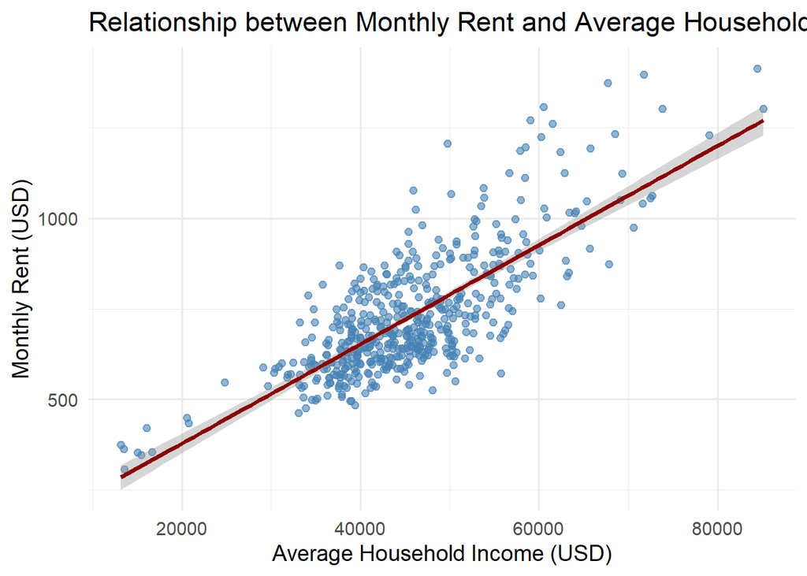

```r
library(ggplot2)
library(dplyr)

rent_income_2009 <- RENT |>
  filter(year == 2009) |>
  inner_join(INCOME |> filter(year == 2009), by = c("GEOID", "NAME"))

ggplot(rent_income_2009, aes(x = household_income, y = monthly_rent)) +
  geom_point(alpha = 0.6, color = "steelblue") +
  geom_smooth(method = "lm", se = TRUE, color = "darkred") +
  labs(
    title = "Relationship between Monthly Rent and Average Household Income per CBSA (2009)",
    x = "Average Household Income (USD)",
    y = "Monthly Rent (USD)"
  ) +
  theme_minimal(base_size = 14)
```

## The relationship between total employment and total employment in the health care and social services sector (NAICS 62) across different CBSAs. Design your visualization so that it is possible to see the evolution of this relationship over time.

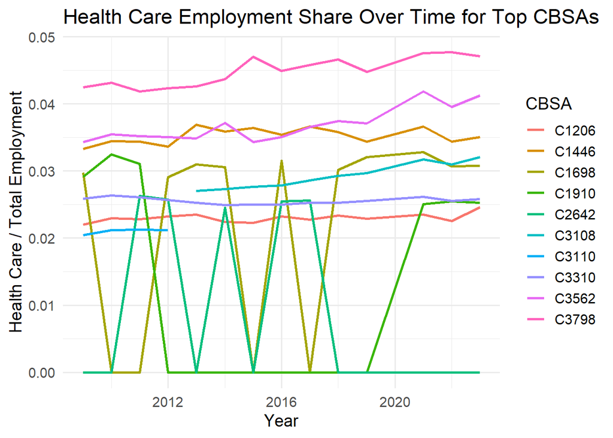

```r
health_wages <- WAGES |>
  filter(INDUSTRY == 62) |>
  group_by(YEAR, FIPS) |>
  summarise(health_emp = sum(EMPLOYMENT, na.rm = TRUE), .groups = "drop") |>
  inner_join(
    WAGES |>
      group_by(YEAR, FIPS) |>
      summarise(total_emp = sum(EMPLOYMENT, na.rm = TRUE), .groups = "drop"),
    by = c("YEAR", "FIPS")
  )
# Compute top 10 CBSAs by average total employment
top_cbsas <- health_wages |>
  group_by(FIPS) |>
  summarise(avg_total = mean(total_emp, na.rm = TRUE)) |>
  arrange(desc(avg_total)) |>
  slice_head(n = 10) |>
  pull(FIPS)

ggplot(health_wages |> filter(FIPS %in% top_cbsas),
       aes(x = YEAR, y = health_emp / total_emp, color = FIPS, group = FIPS)) +
  geom_line(size = 1) +
  labs(
    title = "Health Care Employment Share Over Time for Top CBSAs",
    x = "Year",
    y = "Health Care / Total Employment",
    color = "CBSA"
  ) +
  theme_minimal(base_size = 14)
```

## The evolution of average household size over time. Use different lines to represent different CBSAs.

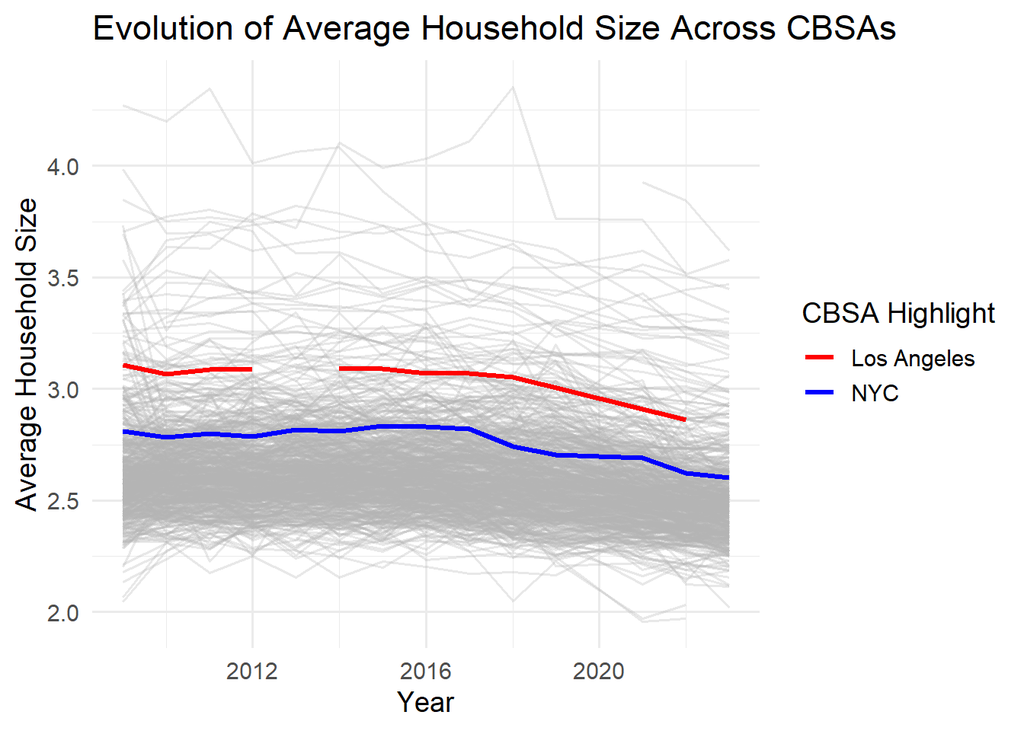

```r
library(dplyr)
library(ggplot2)

# Identify GEOIDs for NYC and LA
nyc_id <- HOUSEHOLDS |> filter(str_detect(NAME, "New York")) |> pull(GEOID) |> unique()
la_id  <- HOUSEHOLDS |> filter(str_detect(NAME, "Los Angeles")) |> pull(GEOID) |> unique()

avg_hh_size <- HOUSEHOLDS |>
  inner_join(POPULATION, by = c("GEOID", "NAME", "year")) |>
  mutate(avg_hh_size = population / households,
         highlight_name = case_when(
           GEOID == nyc_id ~ "NYC",
           GEOID == la_id  ~ "Los Angeles",
           TRUE            ~ "Other"
         ))
ggplot(avg_hh_size, aes(x = year, y = avg_hh_size, group = GEOID, color = highlight_name)) +
  geom_line(data = avg_hh_size |> filter(highlight_name == "Other"),
            color = "gray70", alpha = 0.3) +  # background lines
  geom_line(data = avg_hh_size |> filter(highlight_name != "Other"),
            size = 1.2) +                    # highlighted lines
  scale_color_manual(values = c("NYC" = "blue", "Los Angeles" = "red", "Other" = "gray70")) +
  labs(
    title = "Evolution of Average Household Size Across CBSAs",
    x = "Year",
    y = "Average Household Size",
    color = "CBSA Highlight"
  ) +
  theme_minimal(base_size = 14)
```

# Task 4: Rent Burden

```r
library(dplyr)
library(DT)
library(stringr)

rent_burden <- RENT |>
  inner_join(INCOME, by = c("GEOID", "NAME", "year")) |>
  mutate(
    monthly_income = household_income / 12,
    rent_burden_ratio = monthly_rent / monthly_income
  ) |>
  # Standardization: scale to 0-100
  mutate(
    rb_scaled = 100 * (rent_burden_ratio - min(rent_burden_ratio, na.rm = TRUE)) /
      (max(rent_burden_ratio, na.rm = TRUE) - min(rent_burden_ratio, na.rm = TRUE))
  )

# --------- Table 1: Rent Burden over Time for NYC ---------
nyc_data <- rent_burden |>
  filter(str_detect(NAME, "New York")) |>
  select(year, NAME, rent_burden_ratio, rb_scaled) |>
  arrange(year)

datatable(nyc_data,
          caption = "Rent Burden in NYC Over Time",
          options = list(pageLength = 10))
```

|  | year | NAME | rent_burden_ratio | rb_scaled |
| --- | --- | --- | --- | --- |
| 1 | 2009 | New York-Northern New Jersey-Long Island, NY-NJ-PA Metro Area | 0.2146707586623627 | 35.37090174586487 |
| 2 | 2010 | New York-Northern New Jersey-Long Island, NY-NJ-PA Metro Area | 0.2228430248518417 | 38.52847000739396 |
| 3 | 2011 | New York-Northern New Jersey-Long Island, NY-NJ-PA Metro Area | 0.2285549244247617 | 40.73541143420564 |
| 4 | 2012 | New York-Northern New Jersey-Long Island, NY-NJ-PA Metro Area | 0.2267512737957551 | 40.03852395538485 |
| 5 | 2013 | New York-Newark-Jersey City, NY-NJ-PA Metro Area | 0.2256407138296902 | 39.60943013733403 |
| 6 | 2014 | New York-Newark-Jersey City, NY-NJ-PA Metro Area | 0.2292070497718665 | 40.98737707639284 |
| 7 | 2015 | New York-Newark-Jersey City, NY-NJ-PA Metro Area | 0.228328702558806 | 40.64800471403232 |
| 8 | 2016 | New York-Newark-Jersey City, NY-NJ-PA Metro Area | 0.2246547143830758 | 39.22846352582998 |
| 9 | 2017 | New York-Newark-Jersey City, NY-NJ-PA Metro Area | 0.2195626791211124 | 37.26102284818027 |
| 10 | 2018 | New York-Newark-Jersey City, NY-NJ-PA Metro Area | 0.2192716430082316 | 37.14857345266569 |

[output cut: 4 more lines]

```r
# --------- Table 2: Highest & Lowest Rent Burden (Latest Year) ---------
latest_year <- max(rent_burden$year, na.rm = TRUE)
rent_extremes <- rent_burden |>
  filter(year == latest_year) |>
  arrange(desc(rent_burden_ratio))

# Extract top 5 and bottom 5 as proper DATAFRAMES
top5_df <- rent_extremes |>
  slice(1:5) |>
  select(NAME, rent_burden_ratio, rb_scaled)

bottom5_df <- rent_extremes |>
  slice((n() - 4):n()) |>
  arrange(rent_burden_ratio)|>
  select(NAME, rent_burden_ratio, rb_scaled)

# Display both results
datatable(top5_df,
          caption = paste("Top 5 CBSAs with Highest Rent Burden in", latest_year),
          options = list(pageLength = 5))
```

|  | NAME | rent_burden_ratio | rb_scaled |
| --- | --- | --- | --- |
| 1 | Clearlake, CA Micro Area | 0.3116883116883117 | 72.85616460236997 |
| 2 | Aguadilla, PR Metro Area | 0.3088774072334429 | 71.77009832808356 |
| 3 | Cape Coral-Fort Myers, FL Metro Area | 0.3013962849595371 | 68.8795715506868 |
| 4 | Miami-Fort Lauderdale-West Palm Beach, FL Metro Area | 0.3011367361120216 | 68.77928808166733 |
| 5 | Port St. Lucie, FL Metro Area | 0.2949235903741437 | 66.3786771212174 |

```r
datatable(bottom5_df,
          caption = paste("Bottom 5 CBSAs with Lowest Rent Burden in", latest_year),
          options = list(pageLength = 5))
```

|  | NAME | rent_burden_ratio | rb_scaled |
| --- | --- | --- | --- |
| 1 | Laconia, NH Micro Area | 0.1273799287556811 | 1.643812142406744 |
| 2 | Manitowoc, WI Micro Area | 0.1321287904300335 | 3.478658750882534 |
| 3 | Bismarck, ND Metro Area | 0.1367689357622243 | 5.271499964090986 |
| 4 | Watertown-Fort Atkinson, WI Micro Area | 0.1380092681984939 | 5.750734761845359 |
| 5 | Wisconsin Rapids-Marshfield, WI Micro Area | 0.1383066760957554 | 5.865646062499009 |

# Task 5: Housing Growth

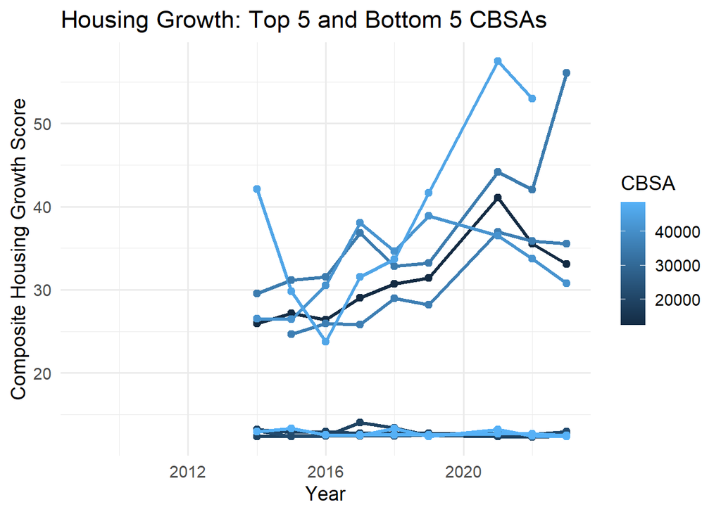

```r
library(dplyr)
library(ggplot2)
library(DT)
library(RcppRoll)  # for rolling functions

# Step 1: Compute 5-year population growth per CBSA
pop_growth <- POPULATION |>
  arrange(GEOID, year) |>
  group_by(GEOID) |>
  mutate(
    pop_lag5 = lag(population, 5),
    pop_growth5yr = (population - pop_lag5) / pop_lag5
  ) |>
  ungroup()

# Step 2: Join PERMITS with population growth
housing_growth <- PERMITS |>
  inner_join(
    pop_growth |> select(GEOID, year, population, pop_growth5yr),
    by = c("CBSA" = "GEOID", "year")
  ) |>
  mutate(
    # Instantaneous growth: new units / population
    growth_instant = new_housing_units_permitted / population,

    # Rate-based growth: new units / population growth
    growth_rate = new_housing_units_permitted / (pop_growth5yr * population)
  )

# Step 3: Scale each metric to 0-100
housing_growth <- housing_growth |>
  mutate(
    growth_instant_scaled = 100 * (growth_instant - min(growth_instant, na.rm = TRUE)) /
      (max(growth_instant, na.rm = TRUE) - min(growth_instant, na.rm = TRUE)),
    growth_rate_scaled = 100 * (growth_rate - min(growth_rate, na.rm = TRUE)) /
      (max(growth_rate, na.rm = TRUE) - min(growth_rate, na.rm = TRUE))
  )

# Step 4: Composite score (average of scaled metrics)
housing_growth <- housing_growth |>
  mutate(composite_score = (growth_instant_scaled + growth_rate_scaled) / 2)

# Step 5: Cumulative composite score over years
housing_growth <- housing_growth |>
  group_by(CBSA) |>
  mutate(composite_cummean = cummean(composite_score))|>
  ungroup()

# Step 6: Identify top 5 and bottom 5 CBSAs
top5_cbsa <- housing_growth |>
  group_by(CBSA) |>
  summarise(avg_composite = mean(composite_score, na.rm = TRUE)) |>
  arrange(desc(avg_composite)) |>
  slice(1:5) |>
  pull(CBSA)

bottom5_cbsa <- housing_growth |>
  group_by(CBSA) |>
  summarise(avg_composite = mean(composite_score, na.rm = TRUE)) |>
  arrange(avg_composite) |>
  slice(1:5) |>
  pull(CBSA)

highlight_cbsas <- c(top5_cbsa, bottom5_cbsa)


# Step 7: Visualization of top/bottom CBSAs
housing_plot_data <- housing_growth|>
  filter(CBSA %in% highlight_cbsas)

ggplot(housing_plot_data, aes(x = year, y = composite_score, group = CBSA)) +
  geom_line(aes(color = CBSA), size = 1.2) +
  geom_point(aes(color = CBSA), size = 2) +
  labs(
    title = "Housing Growth: Top 5 and Bottom 5 CBSAs",
    x = "Year",
    y = "Composite Housing Growth Score",
    color = "CBSA"
  ) +
  theme_minimal(base_size = 14)
```

```r
# Step 8: Display full metrics as a datatable
housing_full <- housing_growth %>%
  select(CBSA, year, population, new_housing_units_permitted,
         growth_instant, growth_rate, growth_instant_scaled,
         growth_rate_scaled, composite_score, composite_cummean)

datatable(
  housing_full,
  caption = "Housing Growth Metrics for All CBSAs",
  options = list(pageLength = 10, scrollX = TRUE)
)
```

|  | CBSA | year | population | new_housing_units_permitted | growth_instant | growth_rate | growth_instant_scaled | growth_rate_scaled | composite_score | composite_cummean |
| --- | --- | --- | --- | --- | --- | --- | --- | --- | --- | --- |
| 1 | 10180 | 2009 | 160266 | 214 | 0.001335280096839005 |  | 3.46827325659286 |  |  |  |
| 2 | 10420 | 2009 | 699935 | 741 | 0.001058669733618122 |  | 2.734610785625126 |  |  |  |
| 3 | 10500 | 2009 | 164238 | 213 | 0.001296898403536331 |  | 3.366472269744513 |  |  |  |
| 4 | 10580 | 2009 | 857592 | 1380 | 0.001609156801835838 |  | 4.194685158839722 |  |  |  |
| 5 | 10740 | 2009 | 856216 | 1692 | 0.001976136862660824 |  | 5.168038055259408 |  |  |  |
| 6 | 10780 | 2009 | 154101 | 396 | 0.002569743220355481 |  | 6.742479092454571 |  |  |  |
| 7 | 10900 | 2009 | 816012 | 1648 | 0.002019578143458675 |  | 5.283258747069513 |  |  |  |
| 8 | 11020 | 2009 | 126122 | 125 | 0.0009911038518260098 |  | 2.555403646704121 |  |  |  |
| 9 | 11100 | 2009 | 245712 | 642 | 0.00261281500293026 |  | 6.856719752366375 |  |  |  |
| 10 | 11180 | 2009 | 87214 | 122 | 0.001398857981516729 |  | 3.63690290382814 |  |  |  |

[output cut: 5245 more lines]